# Sessões, buscas e navegação na wikimedia

Hugo Gabriel

## Qual o clickthrough rate diário? Como ele varia entre os grupos?

O *clickthrough rate* é dado pela razão entre o número de sessões em que pelo menos um página foi visitada e o número total de sessões. As visualizações abaixo buscam nos ajudar a compreender o comportamento desta variável ao longo do tempo.

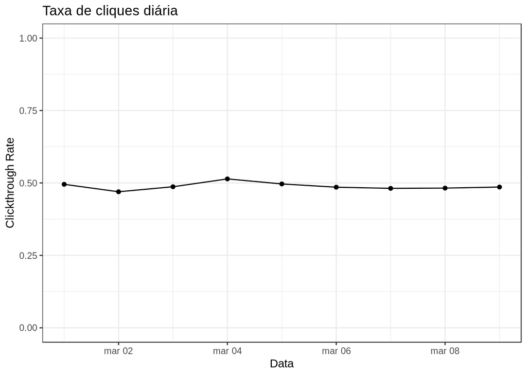

```r
clickRateData <- buscas %>%
    mutate(date = round_date(session_start_date, unit = "day"),
           hasClick = ifelse(num_clicks > 0, 1, 0)) %>%
    group_by(date, session_id) %>%
    summarise(hasClick = sum(hasClick)) %>%
    group_by(date) %>%
    summarise(clickRate = sum(hasClick)/n())

clickRateData %>%
    ggplot(aes(x=date, y=clickRate)) +
    geom_line() +
    geom_point() +
    ylim(0,1) +
    labs(x = "Data", y = "Clickthrough Rate", title="Taxa de cliques diária")
```

Percebemos que a taixa de cliques ( *clickthrough rate* ) não apresenta variações bruscas entre os dias observados, a média observada é 0.49, o que indica que aproximadamente metade das sessões retorna pelo menos um resultado de interesse do usuário; Por outro lado esse resultado pode ser lido como: aproximadamente metade das sessões não retorna nenhum resultado de interesse.

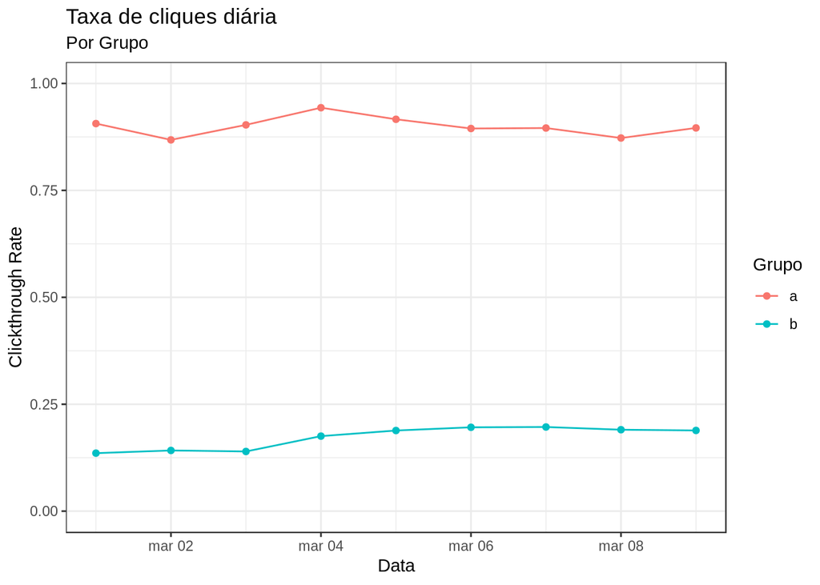

```r
clickRateGroupData <- buscas %>%
    mutate(date = round_date(session_start_date, unit = "day"),
           hasClick = ifelse(num_clicks > 0, 1, 0)) %>%
    group_by(group, date, session_id) %>%
    summarise(hasClick = sum(hasClick)) %>%
    group_by(group, date) %>%
    summarise(clickRate = sum(hasClick)/n())

clickRateGroupData %>%
    ggplot(aes(x=date, y=clickRate, color=group)) +
    geom_line() +
    geom_point() +
    ylim(0,1) +
    labs(x = "Data", y = "Clickthrough Rate", title="Taxa de cliques diária", subtitle="Por Grupo", color="Grupo")
```

Diferenciando a taixa de cliques por grupos, podemos ver delineado comportamentos bastantes distintos desta variável. Enquanto o grupo A apresenta um *clickthrough rate* de 0.9 o grupo B tem 0.17. Mesmo com essa diferenciação o comportamento observado, na visão geral, se repete e a taxa de cliques não varia muito de um dia para outro em nemhum dos grupos.

## Em que resultados a pessoa tende a clicar primeiro? Como isso varia através do tempo?

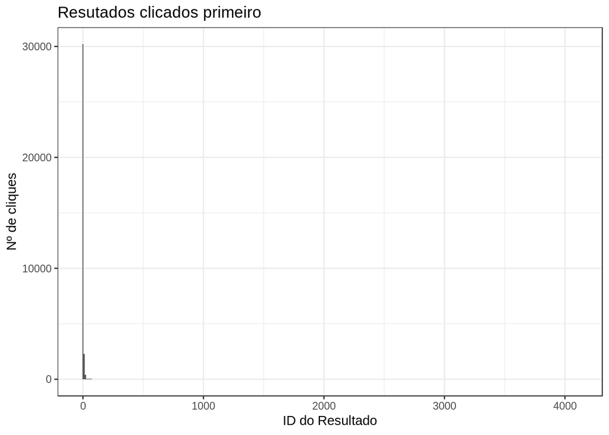

```r
buscas %>%
    filter(!is.na(first_click)) %>%
    ggplot(aes(x=first_click)) +
    geom_histogram(binwidth = 10) +
    labs(x = "ID do Resultado", y = "Nº de cliques", title="Resutados clicados primeiro")
```

```r
fClick <- (buscas %>%
    filter(!is.na(first_click)))$first_click
```

Através do gráfico acima percebemos que na grande maioria das buscas o usuário clica nos primeiros resultados, mas esse comportamento já era esperado.

Temos que o 95-percentil para o primeiro clique é 9, ou seja em 95% das buscas o usuário clica primeiro num resultado na 9ª posição ou menor.

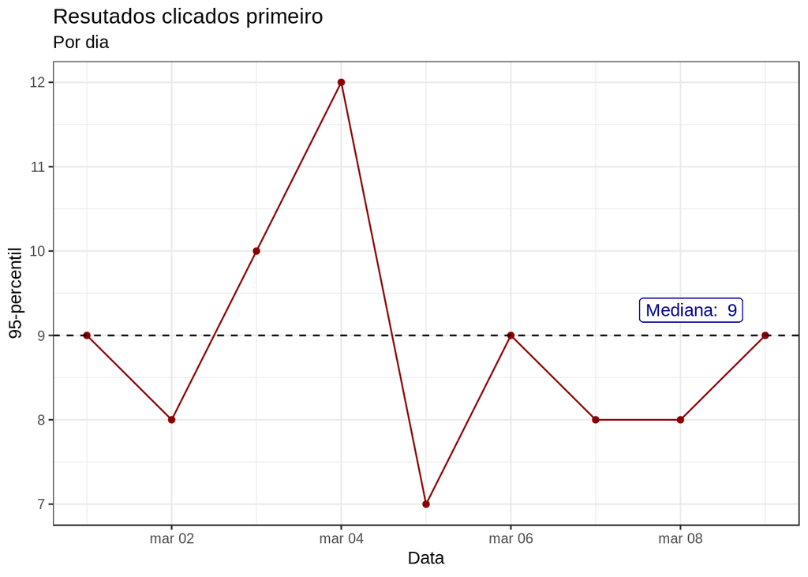

```r
perc95Data <- buscas %>%
    mutate(date = round_date(session_start_date, unit = "day")) %>%
    filter(!is.na(first_click)) %>%
    group_by(date) %>%
    summarise(perc95 = quantile(first_click, .95))

median95perc <- median(perc95Data$perc95)

perc95Data %>%
    ggplot(aes(x=date, y=perc95)) +
    geom_line(color="darkred") +
    geom_point(color="darkred") +
    geom_hline(yintercept = median95perc, linetype='dashed') +
    geom_label(aes(x=as.POSIXct("2016-03-08"), y=median95perc+.3, label=paste("Mediana: ", median95perc)), color="darkblue") +
    labs(x = "Data", y = "95-percentil", title="Resutados clicados primeiro", subtitle="Por dia")
```

O gráfico acima mostra o 95-percentil do *first click* por dia e com eles podemos ver que a variação não é muito grande de um dia para o outro, sendo que o menor 95-percentil é 7 e o maior é 12 o que nos dá ainda mais evidências que a imensa maioria dos usuários, quando clica, clica nos primeiros resultados da busca, independentemente do dia.

## Qual o zero results rate diário geral? Como ele varia entre os grupos?

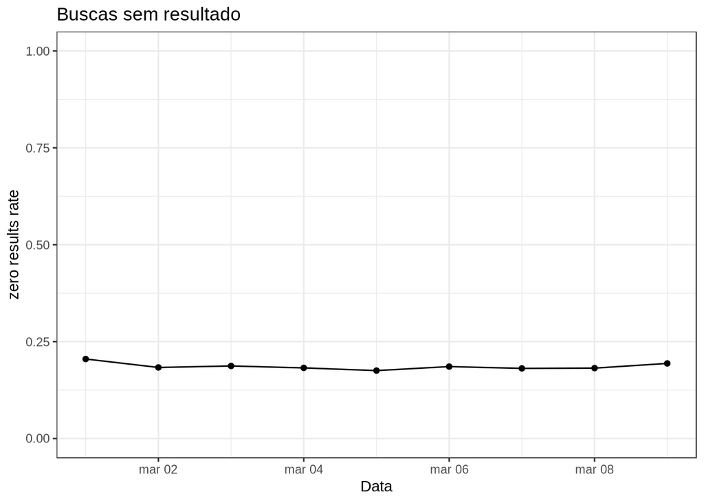

```r
zeroResultsData <- buscas %>%
    mutate(date = round_date(session_start_date, unit = "day"),
           zeroResult= ifelse(results > 0, 0, 1)) %>%
    group_by(date) %>%
    summarise(zeroResult = sum(zeroResult)/n())

zeroResultsData %>%
    ggplot(aes(x=date, y=zeroResult)) +
    geom_line() +
    geom_point() +
    ylim(0,1) +
    labs(x = "Data", y = "zero results rate", title="Buscas sem resultado")
```

Percebemos que não há grande variação o *zero results rate* para os dias estudados, tem-se uma taixa baixa para todos dos dias. A média é de 0.19.

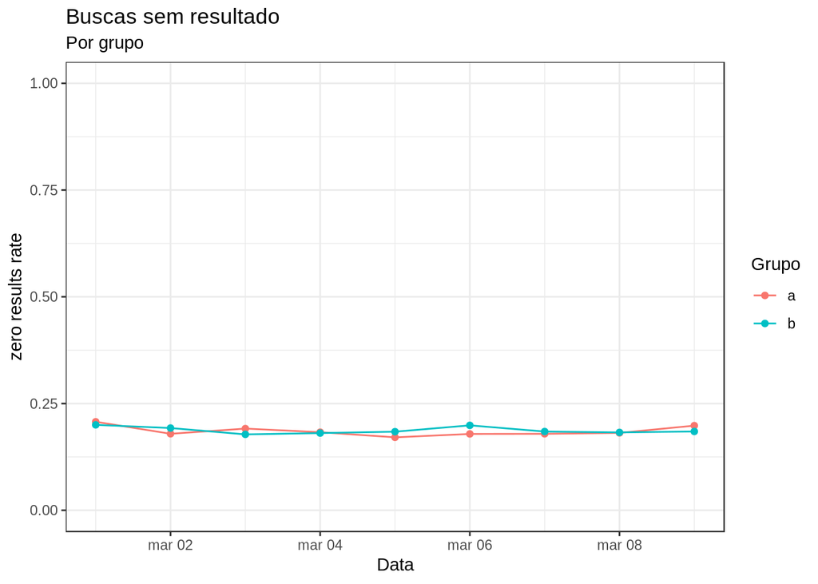

```r
zeroResultsGroupData <- buscas %>%
    mutate(date = round_date(session_start_date, unit = "day"),
           zeroResult= ifelse(results > 0, 0, 1)) %>%
    group_by(date, group) %>%
    summarise(zeroResult = sum(zeroResult)/n())

zeroResultsGroupData %>%
    ggplot(aes(x=date, y=zeroResult, color=group)) +
    geom_line() +
    geom_point() +
    ylim(0,1) +
    labs(x = "Data", y = "zero results rate", title="Buscas sem resultado", subtitle="Por grupo", color="Grupo")
```

Neste caso não foi possível observar uma diferenciação clara entre os grupos como a vista para o *clickthrough rate*. Os dois grupos apresentam comportamentos bem semelhantes mantendo *zero results rate* baixo para todos dos dias.

## Como a duração da sessão varia entre os grupos?

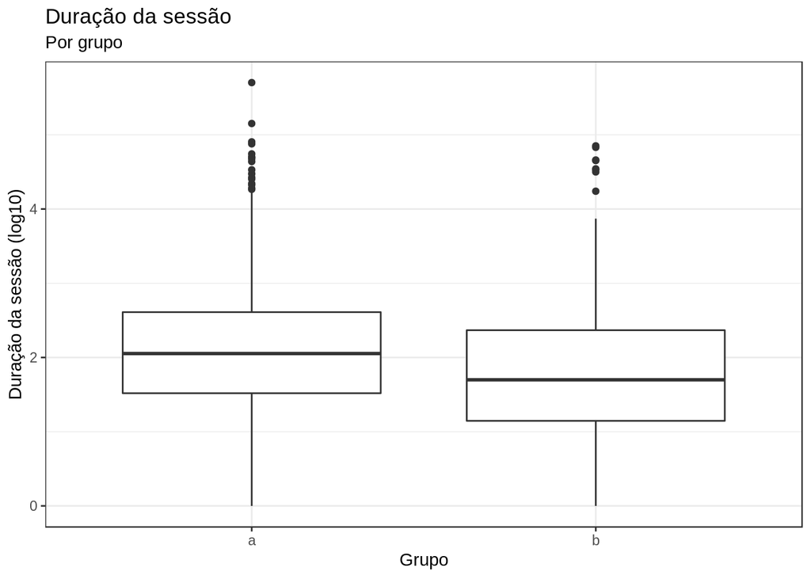

```r
buscas %>%
    filter(!is.na(session_length), session_length > 0) %>%
    group_by(session_id, group) %>%
    summarise(session_length=first(session_length),
              num_clicks= sum(num_clicks)) %>%
    ggplot(aes(x=group, y=log10(session_length))) +
    geom_boxplot() +
    labs(x = "Grupo", y = "Duração da sessão (log10)", title="Duração da sessão", subtitle="Por grupo")
```

O gráfico acima exibe a duração da sessão por grupo (foi utilizado log10 para facilitar a visualização dos dados). Vê-se que o as sessões do grupo A são ligeiramente mais longas que as sessões do grupo B, mas essa diferença não é muito grande e as distribruições também são parecidas.